# Risk Factor Analysis

## Outcome Variable

**Outcome Variable:** wast_rec90d

## Predictor Variables

**Intervention Variable:** exclfeed6

**Adjustment Set:**

- arm
- sex
- W_mage
- meducyrs
- feducyrs
- hhwealth_quart
- hfoodsec
- W_mhtcm
- vagbrth
- W_gagebrth
- W_birthwt
- W_birthlen
- W_nrooms
- W_nchldlt5
- month
- brthmon
- W_parity
- impfloor
- impsan
- safeh20
- delta_W_mage
- delta_meducyrs
- delta_feducyrs
- delta_hhwealth_quart
- delta_hfoodsec
- delta_W_mhtcm
- delta_vagbrth
- delta_W_gagebrth
- delta_W_birthwt
- delta_W_birthlen
- delta_W_nrooms
- delta_W_nchldlt5
- delta_month
- delta_brthmon
- delta_W_parity
- delta_impfloor
- delta_impsan
- delta_safeh20

## Stratifying Variables

The analysis was stratified on these variable(s):

- agecat
- studyid
- country

## Data Summary

| agecat | studyid | country | exclfeed6 | wast_rec90d | n_cell | n |
| --- | --- | --- | --- | --- | --- | --- |
| 0-24 months | ki0047075b-MAL-ED | BANGLADESH | 0 | 0 | 28 | 121 |
| 0-24 months | ki0047075b-MAL-ED | BANGLADESH | 0 | 1 | 57 | 121 |
| 0-24 months | ki0047075b-MAL-ED | BANGLADESH | 1 | 0 | 16 | 121 |
| 0-24 months | ki0047075b-MAL-ED | BANGLADESH | 1 | 1 | 20 | 121 |
| 0-24 months | ki0047075b-MAL-ED | BRAZIL | 0 | 0 | 6 | 23 |
| 0-24 months | ki0047075b-MAL-ED | BRAZIL | 0 | 1 | 17 | 23 |
| 0-24 months | ki0047075b-MAL-ED | BRAZIL | 1 | 0 | 0 | 23 |
| 0-24 months | ki0047075b-MAL-ED | BRAZIL | 1 | 1 | 0 | 23 |
| 0-24 months | ki0047075b-MAL-ED | INDIA | 0 | 0 | 66 | 170 |
| 0-24 months | ki0047075b-MAL-ED | INDIA | 0 | 1 | 101 | 170 |
| 0-24 months | ki0047075b-MAL-ED | INDIA | 1 | 0 | 0 | 170 |
| 0-24 months | ki0047075b-MAL-ED | INDIA | 1 | 1 | 3 | 170 |
| 0-24 months | ki0047075b-MAL-ED | NEPAL | 0 | 0 | 18 | 90 |
| 0-24 months | ki0047075b-MAL-ED | NEPAL | 0 | 1 | 71 | 90 |
| 0-24 months | ki0047075b-MAL-ED | NEPAL | 1 | 0 | 0 | 90 |
| 0-24 months | ki0047075b-MAL-ED | NEPAL | 1 | 1 | 1 | 90 |
| 0-24 months | ki0047075b-MAL-ED | PERU | 0 | 0 | 5 | 29 |
| 0-24 months | ki0047075b-MAL-ED | PERU | 0 | 1 | 24 | 29 |
| 0-24 months | ki0047075b-MAL-ED | PERU | 1 | 0 | 0 | 29 |
| 0-24 months | ki0047075b-MAL-ED | PERU | 1 | 1 | 0 | 29 |
| 0-24 months | ki0047075b-MAL-ED | SOUTH AFRICA | 0 | 0 | 12 | 77 |
| 0-24 months | ki0047075b-MAL-ED | SOUTH AFRICA | 0 | 1 | 65 | 77 |
| 0-24 months | ki0047075b-MAL-ED | SOUTH AFRICA | 1 | 0 | 0 | 77 |
| 0-24 months | ki0047075b-MAL-ED | SOUTH AFRICA | 1 | 1 | 0 | 77 |
| 0-24 months | ki0047075b-MAL-ED | TANZANIA, UNITED REPUBLIC OF | 0 | 0 | 8 | 45 |
| 0-24 months | ki0047075b-MAL-ED | TANZANIA, UNITED REPUBLIC OF | 0 | 1 | 37 | 45 |
| 0-24 months | ki0047075b-MAL-ED | TANZANIA, UNITED REPUBLIC OF | 1 | 0 | 0 | 45 |
| 0-24 months | ki0047075b-MAL-ED | TANZANIA, UNITED REPUBLIC OF | 1 | 1 | 0 | 45 |
| 0-24 months | ki1000108-CMC-V-BCS-2002 | INDIA | 0 | 0 | 0 | 16 |
| 0-24 months | ki1000108-CMC-V-BCS-2002 | INDIA | 0 | 1 | 0 | 16 |

[output cut: 186 more lines]

The following strata were considered:

- agecat: 0-24 months, studyid: ki0047075b-MAL-ED, country: BANGLADESH
- agecat: 0-24 months, studyid: ki0047075b-MAL-ED, country: BRAZIL
- agecat: 0-24 months, studyid: ki0047075b-MAL-ED, country: INDIA
- agecat: 0-24 months, studyid: ki0047075b-MAL-ED, country: NEPAL
- agecat: 0-24 months, studyid: ki0047075b-MAL-ED, country: PERU
- agecat: 0-24 months, studyid: ki0047075b-MAL-ED, country: SOUTH AFRICA
- agecat: 0-24 months, studyid: ki0047075b-MAL-ED, country: TANZANIA, UNITED REPUBLIC OF
- agecat: 0-24 months, studyid: ki1000108-CMC-V-BCS-2002, country: INDIA
- agecat: 0-24 months, studyid: ki1000108-IRC, country: INDIA
- agecat: 0-24 months, studyid: ki1000109-EE, country: PAKISTAN
- agecat: 0-24 months, studyid: ki1000304b-SAS-CompFeed, country: INDIA
- agecat: 0-24 months, studyid: ki1000304b-SAS-FoodSuppl, country: INDIA
- agecat: 0-24 months, studyid: ki1017093b-PROVIDE, country: BANGLADESH
- agecat: 0-24 months, studyid: ki1101329-Keneba, country: GAMBIA
- agecat: 0-24 months, studyid: ki1113344-GMS-Nepal, country: NEPAL
- agecat: 0-24 months, studyid: ki1148112-LCNI-5, country: MALAWI
- agecat: 0-24 months, studyid: kiGH5241-JiVitA-3, country: BANGLADESH
- agecat: 0-24 months, studyid: kiGH5241-JiVitA-4, country: BANGLADESH
- agecat: 0-6 months, studyid: ki0047075b-MAL-ED, country: BANGLADESH
- agecat: 0-6 months, studyid: ki0047075b-MAL-ED, country: BRAZIL
- agecat: 0-6 months, studyid: ki0047075b-MAL-ED, country: INDIA
- agecat: 0-6 months, studyid: ki0047075b-MAL-ED, country: NEPAL
- agecat: 0-6 months, studyid: ki0047075b-MAL-ED, country: PERU
- agecat: 0-6 months, studyid: ki0047075b-MAL-ED, country: SOUTH AFRICA
- agecat: 0-6 months, studyid: ki0047075b-MAL-ED, country: TANZANIA, UNITED REPUBLIC OF
- agecat: 0-6 months, studyid: ki1000108-CMC-V-BCS-2002, country: INDIA
- agecat: 0-6 months, studyid: ki1000108-IRC, country: INDIA
- agecat: 0-6 months, studyid: ki1000109-EE, country: PAKISTAN
- agecat: 0-6 months, studyid: ki1000304b-SAS-CompFeed, country: INDIA
- agecat: 0-6 months, studyid: ki1000304b-SAS-FoodSuppl, country: INDIA
- agecat: 0-6 months, studyid: ki1017093b-PROVIDE, country: BANGLADESH
- agecat: 0-6 months, studyid: ki1101329-Keneba, country: GAMBIA
- agecat: 0-6 months, studyid: ki1113344-GMS-Nepal, country: NEPAL
- agecat: 0-6 months, studyid: ki1148112-LCNI-5, country: MALAWI
- agecat: 0-6 months, studyid: kiGH5241-JiVitA-3, country: BANGLADESH
- agecat: 0-6 months, studyid: kiGH5241-JiVitA-4, country: BANGLADESH
- agecat: 6-24 months, studyid: ki0047075b-MAL-ED, country: BANGLADESH
- agecat: 6-24 months, studyid: ki0047075b-MAL-ED, country: BRAZIL
- agecat: 6-24 months, studyid: ki0047075b-MAL-ED, country: INDIA
- agecat: 6-24 months, studyid: ki0047075b-MAL-ED, country: NEPAL
- agecat: 6-24 months, studyid: ki0047075b-MAL-ED, country: PERU
- agecat: 6-24 months, studyid: ki0047075b-MAL-ED, country: SOUTH AFRICA
- agecat: 6-24 months, studyid: ki0047075b-MAL-ED, country: TANZANIA, UNITED REPUBLIC OF
- agecat: 6-24 months, studyid: ki1000108-CMC-V-BCS-2002, country: INDIA
- agecat: 6-24 months, studyid: ki1000108-IRC, country: INDIA
- agecat: 6-24 months, studyid: ki1000109-EE, country: PAKISTAN
- agecat: 6-24 months, studyid: ki1000304b-SAS-CompFeed, country: INDIA
- agecat: 6-24 months, studyid: ki1000304b-SAS-FoodSuppl, country: INDIA
- agecat: 6-24 months, studyid: ki1017093b-PROVIDE, country: BANGLADESH
- agecat: 6-24 months, studyid: ki1101329-Keneba, country: GAMBIA
- agecat: 6-24 months, studyid: ki1113344-GMS-Nepal, country: NEPAL
- agecat: 6-24 months, studyid: ki1148112-LCNI-5, country: MALAWI
- agecat: 6-24 months, studyid: kiGH5241-JiVitA-3, country: BANGLADESH
- agecat: 6-24 months, studyid: kiGH5241-JiVitA-4, country: BANGLADESH

### Dropped Strata

Some strata were dropped due to rare outcomes:

- agecat: 0-24 months, studyid: ki0047075b-MAL-ED, country: BRAZIL
- agecat: 0-24 months, studyid: ki0047075b-MAL-ED, country: INDIA
- agecat: 0-24 months, studyid: ki0047075b-MAL-ED, country: NEPAL
- agecat: 0-24 months, studyid: ki0047075b-MAL-ED, country: PERU
- agecat: 0-24 months, studyid: ki0047075b-MAL-ED, country: SOUTH AFRICA
- agecat: 0-24 months, studyid: ki0047075b-MAL-ED, country: TANZANIA, UNITED REPUBLIC OF
- agecat: 0-24 months, studyid: ki1000108-CMC-V-BCS-2002, country: INDIA
- agecat: 0-24 months, studyid: ki1000108-IRC, country: INDIA
- agecat: 0-24 months, studyid: ki1000304b-SAS-FoodSuppl, country: INDIA
- agecat: 0-24 months, studyid: ki1148112-LCNI-5, country: MALAWI
- agecat: 0-6 months, studyid: ki0047075b-MAL-ED, country: BANGLADESH
- agecat: 0-6 months, studyid: ki0047075b-MAL-ED, country: BRAZIL
- agecat: 0-6 months, studyid: ki0047075b-MAL-ED, country: INDIA
- agecat: 0-6 months, studyid: ki0047075b-MAL-ED, country: NEPAL
- agecat: 0-6 months, studyid: ki0047075b-MAL-ED, country: PERU
- agecat: 0-6 months, studyid: ki0047075b-MAL-ED, country: SOUTH AFRICA
- agecat: 0-6 months, studyid: ki0047075b-MAL-ED, country: TANZANIA, UNITED REPUBLIC OF
- agecat: 0-6 months, studyid: ki1000108-CMC-V-BCS-2002, country: INDIA
- agecat: 0-6 months, studyid: ki1000108-IRC, country: INDIA
- agecat: 0-6 months, studyid: ki1000304b-SAS-CompFeed, country: INDIA
- agecat: 0-6 months, studyid: ki1000304b-SAS-FoodSuppl, country: INDIA
- agecat: 0-6 months, studyid: ki1148112-LCNI-5, country: MALAWI
- agecat: 6-24 months, studyid: ki0047075b-MAL-ED, country: BRAZIL
- agecat: 6-24 months, studyid: ki0047075b-MAL-ED, country: INDIA
- agecat: 6-24 months, studyid: ki0047075b-MAL-ED, country: NEPAL
- agecat: 6-24 months, studyid: ki0047075b-MAL-ED, country: PERU
- agecat: 6-24 months, studyid: ki0047075b-MAL-ED, country: SOUTH AFRICA
- agecat: 6-24 months, studyid: ki0047075b-MAL-ED, country: TANZANIA, UNITED REPUBLIC OF
- agecat: 6-24 months, studyid: ki1000108-CMC-V-BCS-2002, country: INDIA
- agecat: 6-24 months, studyid: ki1000108-IRC, country: INDIA
- agecat: 6-24 months, studyid: ki1000304b-SAS-CompFeed, country: INDIA
- agecat: 6-24 months, studyid: ki1000304b-SAS-FoodSuppl, country: INDIA
- agecat: 6-24 months, studyid: ki1148112-LCNI-5, country: MALAWI
- agecat: 6-24 months, studyid: kiGH5241-JiVitA-3, country: BANGLADESH

## Methods Detail

We’re interested in the causal parameters $E[Y_a]$ for all values of $a \in \mathcal{A}$. These parameters represent the mean outcome if, possibly contrary to fact, we intervened to set all units to have $A=a$. Under the randomization and positivity assumptions, these are identified by the statistical parameters $\psi_a=E_W[E_{Y|A,W}(Y|A=a,W)]$. In addition, we’re interested in the mean of $Y$, $E[Y]$ under no intervention (the observed mean). We will estimate these parameters by using SuperLearner to fit the relevant likelihood factors – $E_{Y|A,W}(Y|A=a,W)$ and $p(A=a|W)$, and then updating our likelihood fit using a joint TMLE.

For unadjusted analyses ($W=\{\}$), initial likelihoods were estimated using Lrnr_glm to estimate the simple $E(Y|A)$ and Lrnr_mean to estimate $p(A)$. For adjusted analyses, a small library containing Lrnr_glmnet, Lrnr_xgboost, and Lrnr_mean was used.

Having estimated these parameters, we will then use the delta method to estimate relative risks and attributable risks relative to a prespecified baseline level of $A$.

# Results Detail

## Results Plots

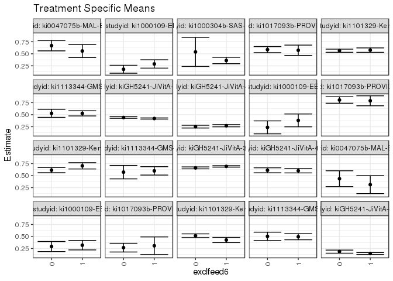

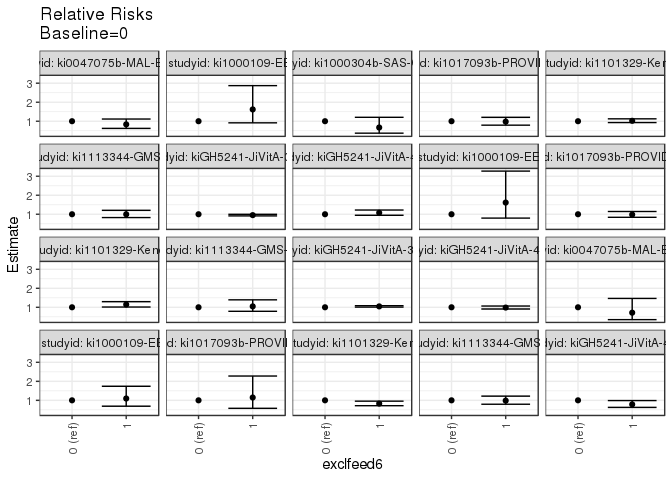

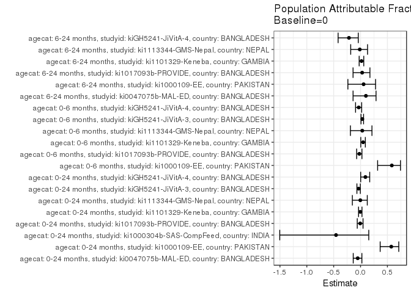

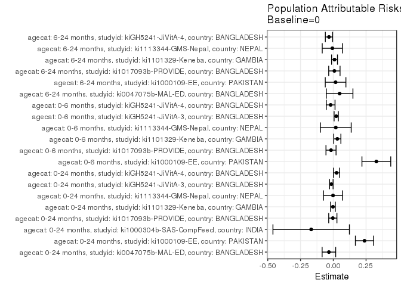

## Results Table

### Parameter: TSM

| agecat | studyid | country | intervention_level | baseline_level | estimate | ci_lower | ci_upper |
| --- | --- | --- | --- | --- | --- | --- | --- |
| 0-24 months | ki0047075b-MAL-ED | BANGLADESH | 0 | NA | 0.6697852 | 0.5609581 | 0.7786122 |
| 0-24 months | ki0047075b-MAL-ED | BANGLADESH | 1 | NA | 0.5576417 | 0.4229127 | 0.6923707 |
| 0-24 months | ki1000109-EE | PAKISTAN | 0 | NA | 0.1781484 | 0.0955471 | 0.2607497 |
| 0-24 months | ki1000109-EE | PAKISTAN | 1 | NA | 0.2885755 | 0.2015515 | 0.3755994 |
| 0-24 months | ki1000304b-SAS-CompFeed | INDIA | 0 | NA | 0.5384615 | 0.2364546 | 0.8404685 |
| 0-24 months | ki1000304b-SAS-CompFeed | INDIA | 1 | NA | 0.3600000 | 0.2937351 | 0.4262649 |
| 0-24 months | ki1017093b-PROVIDE | BANGLADESH | 0 | NA | 0.5865521 | 0.5228518 | 0.6502524 |
| 0-24 months | ki1017093b-PROVIDE | BANGLADESH | 1 | NA | 0.5730920 | 0.4656907 | 0.6804932 |
| 0-24 months | ki1101329-Keneba | GAMBIA | 0 | NA | 0.5636685 | 0.5305895 | 0.5967474 |
| 0-24 months | ki1101329-Keneba | GAMBIA | 1 | NA | 0.5759352 | 0.5296768 | 0.6221936 |
| 0-24 months | ki1113344-GMS-Nepal | NEPAL | 0 | NA | 0.5281190 | 0.4437620 | 0.6124760 |
| 0-24 months | ki1113344-GMS-Nepal | NEPAL | 1 | NA | 0.5273462 | 0.4738242 | 0.5808681 |
| 0-24 months | kiGH5241-JiVitA-3 | BANGLADESH | 0 | NA | 0.4412576 | 0.4243251 | 0.4581902 |
| 0-24 months | kiGH5241-JiVitA-3 | BANGLADESH | 1 | NA | 0.4204135 | 0.4082213 | 0.4326058 |
| 0-24 months | kiGH5241-JiVitA-4 | BANGLADESH | 0 | NA | 0.2516538 | 0.2227760 | 0.2805316 |
| 0-24 months | kiGH5241-JiVitA-4 | BANGLADESH | 1 | NA | 0.2705289 | 0.2477728 | 0.2932849 |
| 0-6 months | ki1000109-EE | PAKISTAN | 0 | NA | 0.2361949 | 0.1016732 | 0.3707165 |
| 0-6 months | ki1000109-EE | PAKISTAN | 1 | NA | 0.3814436 | 0.2478216 | 0.5150655 |
| 0-6 months | ki1017093b-PROVIDE | BANGLADESH | 0 | NA | 0.8053921 | 0.7382206 | 0.8725636 |
| 0-6 months | ki1017093b-PROVIDE | BANGLADESH | 1 | NA | 0.7895110 | 0.6856901 | 0.8933318 |
| 0-6 months | ki1101329-Keneba | GAMBIA | 0 | NA | 0.6134653 | 0.5594744 | 0.6674563 |
| 0-6 months | ki1101329-Keneba | GAMBIA | 1 | NA | 0.7031477 | 0.6377938 | 0.7685017 |
| 0-6 months | ki1113344-GMS-Nepal | NEPAL | 0 | NA | 0.5714286 | 0.4318973 | 0.7109598 |
| 0-6 months | ki1113344-GMS-Nepal | NEPAL | 1 | NA | 0.5983607 | 0.5108507 | 0.6858706 |
| 0-6 months | kiGH5241-JiVitA-3 | BANGLADESH | 0 | NA | 0.6604166 | 0.6401345 | 0.6806988 |
| 0-6 months | kiGH5241-JiVitA-3 | BANGLADESH | 1 | NA | 0.6911067 | 0.6763927 | 0.7058208 |
| 0-6 months | kiGH5241-JiVitA-4 | BANGLADESH | 0 | NA | 0.6102249 | 0.5585177 | 0.6619320 |
| 0-6 months | kiGH5241-JiVitA-4 | BANGLADESH | 1 | NA | 0.6010326 | 0.5558581 | 0.6462070 |
| 6-24 months | ki0047075b-MAL-ED | BANGLADESH | 0 | NA | 0.4355975 | 0.2706067 | 0.6005883 |
| 6-24 months | ki0047075b-MAL-ED | BANGLADESH | 1 | NA | 0.3116381 | 0.1255947 | 0.4976816 |
| 6-24 months | ki1000109-EE | PAKISTAN | 0 | NA | 0.2911894 | 0.1864846 | 0.3958942 |
| 6-24 months | ki1000109-EE | PAKISTAN | 1 | NA | 0.3191345 | 0.2208993 | 0.4173696 |
| 6-24 months | ki1017093b-PROVIDE | BANGLADESH | 0 | NA | 0.2680412 | 0.1773699 | 0.3587126 |
| 6-24 months | ki1017093b-PROVIDE | BANGLADESH | 1 | NA | 0.3076923 | 0.1243207 | 0.4910639 |
| 6-24 months | ki1101329-Keneba | GAMBIA | 0 | NA | 0.5154023 | 0.4763623 | 0.5544422 |
| 6-24 months | ki1101329-Keneba | GAMBIA | 1 | NA | 0.4270746 | 0.3739312 | 0.4802180 |
| 6-24 months | ki1113344-GMS-Nepal | NEPAL | 0 | NA | 0.5029726 | 0.4159151 | 0.5900300 |
| 6-24 months | ki1113344-GMS-Nepal | NEPAL | 1 | NA | 0.4951866 | 0.4318445 | 0.5585286 |
| 6-24 months | kiGH5241-JiVitA-4 | BANGLADESH | 0 | NA | 0.1849966 | 0.1526270 | 0.2173663 |
| 6-24 months | kiGH5241-JiVitA-4 | BANGLADESH | 1 | NA | 0.1455557 | 0.1246883 | 0.1664231 |

### Parameter: E(Y)

| agecat | studyid | country | intervention_level | baseline_level | estimate | ci_lower | ci_upper |
| --- | --- | --- | --- | --- | --- | --- | --- |
| 0-24 months | ki0047075b-MAL-ED | BANGLADESH | NA | NA | 0.6363636 | 0.5494154 | 0.7233119 |
| 0-24 months | ki1000109-EE | PAKISTAN | NA | NA | 0.4163424 | 0.3511349 | 0.4815500 |
| 0-24 months | ki1000304b-SAS-CompFeed | INDIA | NA | NA | 0.3697479 | 0.3045176 | 0.4349782 |
| 0-24 months | ki1017093b-PROVIDE | BANGLADESH | NA | NA | 0.5830619 | 0.5262762 | 0.6398476 |
| 0-24 months | ki1101329-Keneba | GAMBIA | NA | NA | 0.5610860 | 0.5320121 | 0.5901599 |
| 0-24 months | ki1113344-GMS-Nepal | NEPAL | NA | NA | 0.5260223 | 0.4802445 | 0.5718001 |
| 0-24 months | kiGH5241-JiVitA-3 | BANGLADESH | NA | NA | 0.4262098 | 0.4150208 | 0.4373989 |
| 0-24 months | kiGH5241-JiVitA-4 | BANGLADESH | NA | NA | 0.2766885 | 0.2556490 | 0.2977279 |
| 0-6 months | ki1000109-EE | PAKISTAN | NA | NA | 0.5648148 | 0.4692893 | 0.6603404 |
| 0-6 months | ki1017093b-PROVIDE | BANGLADESH | NA | NA | 0.7880435 | 0.7295878 | 0.8464992 |
| 0-6 months | ki1101329-Keneba | GAMBIA | NA | NA | 0.6442786 | 0.5973688 | 0.6911884 |
| 0-6 months | ki1113344-GMS-Nepal | NEPAL | NA | NA | 0.5906433 | 0.5164645 | 0.6648221 |
| 0-6 months | kiGH5241-JiVitA-3 | BANGLADESH | NA | NA | 0.6828279 | 0.6694976 | 0.6961581 |
| 0-6 months | kiGH5241-JiVitA-4 | BANGLADESH | NA | NA | 0.5900383 | 0.5478064 | 0.6322702 |
| 6-24 months | ki0047075b-MAL-ED | BANGLADESH | NA | NA | 0.4838710 | 0.3544124 | 0.6133295 |
| 6-24 months | ki1000109-EE | PAKISTAN | NA | NA | 0.3087248 | 0.2336906 | 0.3837591 |
| 6-24 months | ki1017093b-PROVIDE | BANGLADESH | NA | NA | 0.2764228 | 0.1950773 | 0.3577682 |
| 6-24 months | ki1101329-Keneba | GAMBIA | NA | NA | 0.5248918 | 0.4904236 | 0.5593599 |
| 6-24 months | ki1113344-GMS-Nepal | NEPAL | NA | NA | 0.4959128 | 0.4403572 | 0.5514684 |
| 6-24 months | kiGH5241-JiVitA-4 | BANGLADESH | NA | NA | 0.1522070 | 0.1331665 | 0.1712475 |

### Parameter: RR

| agecat | studyid | country | intervention_level | baseline_level | estimate | ci_lower | ci_upper |
| --- | --- | --- | --- | --- | --- | --- | --- |
| 0-24 months | ki0047075b-MAL-ED | BANGLADESH | 0 | 0 | 1.0000000 | 1.0000000 | 1.0000000 |
| 0-24 months | ki0047075b-MAL-ED | BANGLADESH | 1 | 0 | 0.8325680 | 0.6222758 | 1.1139266 |
| 0-24 months | ki1000109-EE | PAKISTAN | 0 | 0 | 1.0000000 | 1.0000000 | 1.0000000 |
| 0-24 months | ki1000109-EE | PAKISTAN | 1 | 0 | 1.6198599 | 0.9137468 | 2.8716337 |
| 0-24 months | ki1000304b-SAS-CompFeed | INDIA | 0 | 0 | 1.0000000 | 1.0000000 | 1.0000000 |
| 0-24 months | ki1000304b-SAS-CompFeed | INDIA | 1 | 0 | 0.6685714 | 0.3704954 | 1.2064597 |
| 0-24 months | ki1017093b-PROVIDE | BANGLADESH | 0 | 0 | 1.0000000 | 1.0000000 | 1.0000000 |
| 0-24 months | ki1017093b-PROVIDE | BANGLADESH | 1 | 0 | 0.9770520 | 0.7931854 | 1.2035405 |
| 0-24 months | ki1101329-Keneba | GAMBIA | 0 | 0 | 1.0000000 | 1.0000000 | 1.0000000 |
| 0-24 months | ki1101329-Keneba | GAMBIA | 1 | 0 | 1.0217623 | 0.9288157 | 1.1240101 |
| 0-24 months | ki1113344-GMS-Nepal | NEPAL | 0 | 0 | 1.0000000 | 1.0000000 | 1.0000000 |
| 0-24 months | ki1113344-GMS-Nepal | NEPAL | 1 | 0 | 0.9985366 | 0.8263001 | 1.2066746 |
| 0-24 months | kiGH5241-JiVitA-3 | BANGLADESH | 0 | 0 | 1.0000000 | 1.0000000 | 1.0000000 |
| 0-24 months | kiGH5241-JiVitA-3 | BANGLADESH | 1 | 0 | 0.9527621 | 0.9122983 | 0.9950206 |
| 0-24 months | kiGH5241-JiVitA-4 | BANGLADESH | 0 | 0 | 1.0000000 | 1.0000000 | 1.0000000 |
| 0-24 months | kiGH5241-JiVitA-4 | BANGLADESH | 1 | 0 | 1.0750039 | 0.9466531 | 1.2207571 |
| 0-6 months | ki1000109-EE | PAKISTAN | 0 | 0 | 1.0000000 | 1.0000000 | 1.0000000 |
| 0-6 months | ki1000109-EE | PAKISTAN | 1 | 0 | 1.6149528 | 0.7976711 | 3.2696091 |
| 0-6 months | ki1017093b-PROVIDE | BANGLADESH | 0 | 0 | 1.0000000 | 1.0000000 | 1.0000000 |
| 0-6 months | ki1017093b-PROVIDE | BANGLADESH | 1 | 0 | 0.9802815 | 0.8388531 | 1.1455543 |
| 0-6 months | ki1101329-Keneba | GAMBIA | 0 | 0 | 1.0000000 | 1.0000000 | 1.0000000 |
| 0-6 months | ki1101329-Keneba | GAMBIA | 1 | 0 | 1.1461898 | 1.0136175 | 1.2961014 |
| 0-6 months | ki1113344-GMS-Nepal | NEPAL | 0 | 0 | 1.0000000 | 1.0000000 | 1.0000000 |
| 0-6 months | ki1113344-GMS-Nepal | NEPAL | 1 | 0 | 1.0471311 | 0.7877525 | 1.3919138 |
| 0-6 months | kiGH5241-JiVitA-3 | BANGLADESH | 0 | 0 | 1.0000000 | 1.0000000 | 1.0000000 |
| 0-6 months | kiGH5241-JiVitA-3 | BANGLADESH | 1 | 0 | 1.0464708 | 1.0107540 | 1.0834496 |
| 0-6 months | kiGH5241-JiVitA-4 | BANGLADESH | 0 | 0 | 1.0000000 | 1.0000000 | 1.0000000 |
| 0-6 months | kiGH5241-JiVitA-4 | BANGLADESH | 1 | 0 | 0.9849362 | 0.9094570 | 1.0666797 |
| 6-24 months | ki0047075b-MAL-ED | BANGLADESH | 0 | 0 | 1.0000000 | 1.0000000 | 1.0000000 |
| 6-24 months | ki0047075b-MAL-ED | BANGLADESH | 1 | 0 | 0.7154269 | 0.3493445 | 1.4651315 |
| 6-24 months | ki1000109-EE | PAKISTAN | 0 | 0 | 1.0000000 | 1.0000000 | 1.0000000 |
| 6-24 months | ki1000109-EE | PAKISTAN | 1 | 0 | 1.0959687 | 0.6905015 | 1.7395289 |
| 6-24 months | ki1017093b-PROVIDE | BANGLADESH | 0 | 0 | 1.0000000 | 1.0000000 | 1.0000000 |
| 6-24 months | ki1017093b-PROVIDE | BANGLADESH | 1 | 0 | 1.1479290 | 0.5784531 | 2.2780429 |
| 6-24 months | ki1101329-Keneba | GAMBIA | 0 | 0 | 1.0000000 | 1.0000000 | 1.0000000 |
| 6-24 months | ki1101329-Keneba | GAMBIA | 1 | 0 | 0.8286239 | 0.7181237 | 0.9561272 |
| 6-24 months | ki1113344-GMS-Nepal | NEPAL | 0 | 0 | 1.0000000 | 1.0000000 | 1.0000000 |
| 6-24 months | ki1113344-GMS-Nepal | NEPAL | 1 | 0 | 0.9845200 | 0.7937686 | 1.2211112 |
| 6-24 months | kiGH5241-JiVitA-4 | BANGLADESH | 0 | 0 | 1.0000000 | 1.0000000 | 1.0000000 |
| 6-24 months | kiGH5241-JiVitA-4 | BANGLADESH | 1 | 0 | 0.7868020 | 0.6275065 | 0.9865355 |

### Parameter: PAR

| agecat | studyid | country | intervention_level | baseline_level | estimate | ci_lower | ci_upper |
| --- | --- | --- | --- | --- | --- | --- | --- |
| 0-24 months | ki0047075b-MAL-ED | BANGLADESH | 0 | NA | -0.0334216 | -0.0851753 | 0.0183322 |
| 0-24 months | ki1000109-EE | PAKISTAN | 0 | NA | 0.2381940 | 0.1686444 | 0.3077436 |
| 0-24 months | ki1000304b-SAS-CompFeed | INDIA | 0 | NA | -0.1687136 | -0.4604384 | 0.1230111 |
| 0-24 months | ki1017093b-PROVIDE | BANGLADESH | 0 | NA | -0.0034902 | -0.0347982 | 0.0278178 |
| 0-24 months | ki1101329-Keneba | GAMBIA | 0 | NA | -0.0025825 | -0.0205019 | 0.0153369 |
| 0-24 months | ki1113344-GMS-Nepal | NEPAL | 0 | NA | -0.0020967 | -0.0749079 | 0.0707145 |
| 0-24 months | kiGH5241-JiVitA-3 | BANGLADESH | 0 | NA | -0.0150478 | -0.0285702 | -0.0015254 |
| 0-24 months | kiGH5241-JiVitA-4 | BANGLADESH | 0 | NA | 0.0250346 | 0.0016104 | 0.0484588 |
| 0-6 months | ki1000109-EE | PAKISTAN | 0 | NA | 0.3286200 | 0.2187359 | 0.4385040 |
| 0-6 months | ki1017093b-PROVIDE | BANGLADESH | 0 | NA | -0.0173486 | -0.0558206 | 0.0211233 |
| 0-6 months | ki1101329-Keneba | GAMBIA | 0 | NA | 0.0308133 | 0.0036120 | 0.0580145 |
| 0-6 months | ki1113344-GMS-Nepal | NEPAL | 0 | NA | 0.0192147 | -0.0982832 | 0.1367127 |
| 0-6 months | kiGH5241-JiVitA-3 | BANGLADESH | 0 | NA | 0.0224112 | 0.0062444 | 0.0385780 |
| 0-6 months | kiGH5241-JiVitA-4 | BANGLADESH | 0 | NA | -0.0201866 | -0.0536300 | 0.0132568 |
| 6-24 months | ki0047075b-MAL-ED | BANGLADESH | 0 | NA | 0.0482735 | -0.0533498 | 0.1498967 |
| 6-24 months | ki1000109-EE | PAKISTAN | 0 | NA | 0.0175354 | -0.0612321 | 0.0963029 |
| 6-24 months | ki1017093b-PROVIDE | BANGLADESH | 0 | NA | 0.0083815 | -0.0348546 | 0.0516177 |
| 6-24 months | ki1101329-Keneba | GAMBIA | 0 | NA | 0.0094895 | -0.0129724 | 0.0319514 |
| 6-24 months | ki1113344-GMS-Nepal | NEPAL | 0 | NA | -0.0070598 | -0.0843676 | 0.0702481 |
| 6-24 months | kiGH5241-JiVitA-4 | BANGLADESH | 0 | NA | -0.0327896 | -0.0605951 | -0.0049841 |

### Parameter: PAF

| agecat | studyid | country | intervention_level | baseline_level | estimate | ci_lower | ci_upper |
| --- | --- | --- | --- | --- | --- | --- | --- |
| 0-24 months | ki0047075b-MAL-ED | BANGLADESH | 0 | NA | -0.0525196 | -0.1360254 | 0.0248479 |
| 0-24 months | ki1000109-EE | PAKISTAN | 0 | NA | 0.5721108 | 0.3653393 | 0.7115165 |
| 0-24 months | ki1000304b-SAS-CompFeed | INDIA | 0 | NA | -0.4562937 | -1.5037815 | 0.1529647 |
| 0-24 months | ki1017093b-PROVIDE | BANGLADESH | 0 | NA | -0.0059860 | -0.0611695 | 0.0463278 |
| 0-24 months | ki1101329-Keneba | GAMBIA | 0 | NA | -0.0046027 | -0.0370708 | 0.0268489 |
| 0-24 months | ki1113344-GMS-Nepal | NEPAL | 0 | NA | -0.0039860 | -0.1524176 | 0.1253277 |
| 0-24 months | kiGH5241-JiVitA-3 | BANGLADESH | 0 | NA | -0.0353061 | -0.0676055 | -0.0039838 |
| 0-24 months | kiGH5241-JiVitA-4 | BANGLADESH | 0 | NA | 0.0904795 | 0.0026583 | 0.1705675 |
| 0-6 months | ki1000109-EE | PAKISTAN | 0 | NA | 0.5818189 | 0.3178576 | 0.7436380 |
| 0-6 months | ki1017093b-PROVIDE | BANGLADESH | 0 | NA | -0.0220148 | -0.0721943 | 0.0258162 |
| 0-6 months | ki1101329-Keneba | GAMBIA | 0 | NA | 0.0478260 | 0.0045426 | 0.0892274 |
| 0-6 months | ki1113344-GMS-Nepal | NEPAL | 0 | NA | 0.0325318 | -0.1884274 | 0.2124091 |
| 0-6 months | kiGH5241-JiVitA-3 | BANGLADESH | 0 | NA | 0.0328212 | 0.0088860 | 0.0561783 |
| 0-6 months | kiGH5241-JiVitA-4 | BANGLADESH | 0 | NA | -0.0342123 | -0.0927387 | 0.0211795 |
| 6-24 months | ki0047075b-MAL-ED | BANGLADESH | 0 | NA | 0.0997652 | -0.1390837 | 0.2885311 |
| 6-24 months | ki1000109-EE | PAKISTAN | 0 | NA | 0.0567995 | -0.2353352 | 0.2798496 |
| 6-24 months | ki1017093b-PROVIDE | BANGLADESH | 0 | NA | 0.0303214 | -0.1393171 | 0.1747016 |
| 6-24 months | ki1101329-Keneba | GAMBIA | 0 | NA | 0.0180790 | -0.0255428 | 0.0598453 |
| 6-24 months | ki1113344-GMS-Nepal | NEPAL | 0 | NA | -0.0142359 | -0.1830749 | 0.1305077 |
| 6-24 months | kiGH5241-JiVitA-4 | BANGLADESH | 0 | NA | -0.2154278 | -0.4174162 | -0.0422237 |